# r with py

2022/07/05

# 1 WindowsでのPythonインストール

- `Add Python 3.x to PATH`にチェックを入れる
  - https://www.python.jp/install/windows/install.html

# 2 パッケージの管理（pip関連）

- 以下，コマンドプロンプトから実行
  - Windowsでは，「ここに入力して検索」にcmdを入れて検索
  - RStudioのTerminalからでもできる？（カレントディレクトリが違うだけみたい）
  - ただし仮想環境あるとできないぽい？
- インストール済みパッケージの確認
  - `pip list`
- パッケージインストール
  - `pip install {ここにパッケージ名}`
- アップデートが必要なパッケージ一覧
  - `pip list -o`
- パッケージのアップデート
  - `pip install -U {ここにパッケージ名}`

# 3 コマンドプロンプト or Terminalの操作

- ルートに移動
  - `cd \`
- ディレクトリに移動しカレントに
  - `cd ここにパス`
- フォルダ作成
  - `mkdir フォルダ名`
- 構造図式化
  - `tree`

# 4 仮想環境:venv

- 以下，コマンドプロンプトまたはRStudioのTerminalから実行
- 作成
  - `python -m venv パス名\myenv` (名前は任意;この丸カッコ部分ごと不要)
  - 該当フォルダがすでにカレントになっていればmyenvだけでOK
- 仮想環境に入る
  - `myenv\Scripts\activate`
- 仮想環境から出る
  - `deactivate`

# 5 基本用語

## 5.1 R

### 5.1.1 ベクトル

```r
r_vec <- c(1, 2, 3)
r_vec
```

```
## [1] 1 2 3
```

### 5.1.2 名前付きベクトル

```r
r_nvec <- c(a = 1, b = 2, c = 3)
r_nvec
```

```
## a b c
## 1 2 3
```

### 5.1.3 リスト

```r
r_l <- list(1, 2, 3)
r_l
```

```
## [[1]]
## [1] 1
##
## [[2]]
## [1] 2
##
## [[3]]
## [1] 3
```

### 5.1.4 名前付きリスト

```r
r_nl <- list(a = 1, b = 2, c = 3)
r_nl
```

```
## $a
## [1] 1
##
## $b
## [1] 2
##
## $c
## [1] 3
```

## 5.2 python

- https://docs.python.org/ja/3/tutorial/datastructures.html#data-structures

### 5.2.1 リスト

```python
py_l = [1,2,3]
py_l
```

```
## [1, 2, 3]
```

```python
py_l2 = [1,'a',3]
py_l2
```

```
## [1, 'a', 3]
```

### 5.2.2 辞書型：dictionary

```python
py_d = {'x':1, 'y':2}
py_d
```

```
## {'x': 1, 'y': 2}
```

### 5.2.3 タプル：tuple

```python
py_t = (3,4,5)
py_t
```

```
## (3, 4, 5)
```

### 5.2.4 np.array 配列

```python
import numpy as np
py_ndarray = np.array([1,2,3])
py_ndarray
```

```
## array([1, 2, 3])
```

```python
py_ndarray2 = np.array([[1,2,3],[4,5,6]])
py_ndarray2
```

```
## array([[1, 2, 3],
##        [4, 5, 6]])
```

### 5.2.5 メソッド

- データに結びついた関数

https://www.python.jp/train/string/method.html

# 6 Rとpythonで相互の読み込み

## 6.1 RとPythonでデータフレームのやり取り

- 緑チャンクがpython

### 6.1.1 Rでデータフレーム読み込み

```r
library(reticulate)

df_r <- palmerpenguins::penguins
```

### 6.1.2 PythonでRのデータフレーム読み込みして列選択

```python
r.df_r.head()
```

```
##   species     island  bill_length_mm  ...  body_mass_g     sex  year
## 0  Adelie  Torgersen            39.1  ...         3750    male  2007
## 1  Adelie  Torgersen            39.5  ...         3800  female  2007
## 2  Adelie  Torgersen            40.3  ...         3250  female  2007
## 3  Adelie  Torgersen             NaN  ...  -2147483648     NaN  2007
## 4  Adelie  Torgersen            36.7  ...         3450  female  2007
##
## [5 rows x 8 columns]
```

```python
df_py = r.df_r[['species',  'bill_length_mm']]
```

### 6.1.3 RからPythonで加工したデータフレーム読み込み

```r
head(py$df_py)
```

```
##   species bill_length_mm
## 1  Adelie           39.1
## 2  Adelie           39.5
## 3  Adelie           40.3
## 4  Adelie             NA
## 5  Adelie           36.7
## 6  Adelie           39.3
```

```r
rm(df_r) # df削除
```

## 6.2 ここまで作ったオブジェクトの整理

### 6.2.1 pythonのオブジェクト削除

```python
del df_py
```

## 6.3 RでPythonの変数を読む

- reticulate cheatsheetより

| R | Python |
| --- | --- |
| single-element vector | scalar |
| multi-element vector | list |
| list of mutiple types | tuple |
| named list | dict |
| matrix/array | numpy ndarray |
| dataframe | pandas DataFrame |
| function | python function |
| NULL, TRUE, FALSE | None, True, False |

- リスト（Python） → ベクトル（R）

```r
py$py_l
```

```
## [1] 1 2 3
```

- 型が混在したリスト（Python） → リスト（R）

```r
py$py_l2
```

```
## [[1]]
## [1] 1
##
## [[2]]
## [1] "a"
##
## [[3]]
## [1] 3
```

- 辞書型（Python） → 名前付きリスト（R）

```r
py$py_d
```

```
## $x
## [1] 1
##
## $y
## [1] 2
```

- タプル（Python） → リスト（R）

```r
py$py_t
```

```
## [[1]]
## [1] 3
##
## [[2]]
## [1] 4
##
## [[3]]
## [1] 5
```

- numpy.ndarray

```r
py$py_ndarray
```

```
## [1] 1 2 3
```

```r
py$py_ndarray2
```

```
##      [,1] [,2] [,3]
## [1,]    1    2    3
## [2,]    4    5    6
```

## 6.4 PythonでRのオブジェクトを読む

- ベクトル（R） → リスト（Python）

```python
r.r_vec
```

```
## [1.0, 2.0, 3.0]
```

- 名前付きベクトル（R） → リスト（Python）

```python
r.r_nvec
```

```
## [1.0, 2.0, 3.0]
```

- リスト（R） → リスト（Python）

```python
r.r_l
```

```
## [1.0, 2.0, 3.0]
```

- 名前付きリスト（R） → 辞書型（Python）

```python
r.r_nl
```

```
## {'a': 1.0, 'b': 2.0, 'c': 3.0}
```

# 7 データフレーム操作の基本動詞

## 7.1 Pythonの資料

- cheatsheet
  - https://pandas.pydata.org/docs/whatsnew/v0.19.2.html
- cookbook
  - https://pandas.pydata.org/docs/user_guide/cookbook.html

## 7.2 ★データフレーム読み込み

### 7.2.1 R

```r
pen_r <-   palmerpenguins::penguins
```

### 7.2.2 Pythonでもペンギン

- ペンギンデータ for python
  - https://pypi.org/project/palmerpenguins/

```python
from palmerpenguins import load_penguins
pen_p = load_penguins()

pen_p
```

```
##        species     island  bill_length_mm  ...  body_mass_g     sex  year
## 0       Adelie  Torgersen            39.1  ...       3750.0    male  2007
## 1       Adelie  Torgersen            39.5  ...       3800.0  female  2007
## 2       Adelie  Torgersen            40.3  ...       3250.0  female  2007
## 3       Adelie  Torgersen             NaN  ...          NaN     NaN  2007
## 4       Adelie  Torgersen            36.7  ...       3450.0  female  2007
## ..         ...        ...             ...  ...          ...     ...   ...
## 339  Chinstrap      Dream            55.8  ...       4000.0    male  2009
## 340  Chinstrap      Dream            43.5  ...       3400.0  female  2009
## 341  Chinstrap      Dream            49.6  ...       3775.0    male  2009
## 342  Chinstrap      Dream            50.8  ...       4100.0    male  2009
## 343  Chinstrap      Dream            50.2  ...       3775.0  female  2009
##
## [344 rows x 8 columns]
```

## 7.3 列を選ぶ

### 7.3.1 列名から

#### 7.3.1.1 R

- 単一

```r
library(tidyverse)

# 列名確認
names(pen_r)
```

```
## [1] "species"           "island"            "bill_length_mm"
## [4] "bill_depth_mm"     "flipper_length_mm" "body_mass_g"
## [7] "sex"               "year"
```

```r
pen_r |>
  select(species)
```

```
## # A tibble: 344 × 1
##   species
##   <fct>
## 1 Adelie
## 2 Adelie
## 3 Adelie
## 4 Adelie
## 5 Adelie
## # … with 339 more rows
```

- 複数列

```r
pen_r |>
  select(species, bill_length_mm)
```

```
## # A tibble: 344 × 2
##   species bill_length_mm
##   <fct>            <dbl>
## 1 Adelie            39.1
## 2 Adelie            39.5
## 3 Adelie            40.3
## 4 Adelie            NA
## 5 Adelie            36.7
## # … with 339 more rows
```

```r
pen_r |>
  select(species:bill_length_mm)
```

```
## # A tibble: 344 × 3
##   species island    bill_length_mm
##   <fct>   <fct>              <dbl>
## 1 Adelie  Torgersen           39.1
## 2 Adelie  Torgersen           39.5
## 3 Adelie  Torgersen           40.3
## 4 Adelie  Torgersen           NA
## 5 Adelie  Torgersen           36.7
## # … with 339 more rows
```

- 列の値（ベクトル）を取り出し

```r
pen_r |> pull(species)
```

```
##   [1] Adelie    Adelie    Adelie    Adelie    Adelie    Adelie    Adelie
##   [8] Adelie    Adelie    Adelie    Adelie    Adelie    Adelie    Adelie
##  [15] Adelie    Adelie    Adelie    Adelie    Adelie    Adelie    Adelie
##  [22] Adelie    Adelie    Adelie    Adelie    Adelie    Adelie    Adelie
##  [29] Adelie    Adelie    Adelie    Adelie    Adelie    Adelie    Adelie
##  [36] Adelie    Adelie    Adelie    Adelie    Adelie    Adelie    Adelie
##  [43] Adelie    Adelie    Adelie    Adelie    Adelie    Adelie    Adelie
##  [50] Adelie    Adelie    Adelie    Adelie    Adelie    Adelie    Adelie
##  [57] Adelie    Adelie    Adelie    Adelie    Adelie    Adelie    Adelie
##  [64] Adelie    Adelie    Adelie    Adelie    Adelie    Adelie    Adelie
##  [71] Adelie    Adelie    Adelie    Adelie    Adelie    Adelie    Adelie
##  [78] Adelie    Adelie    Adelie    Adelie    Adelie    Adelie    Adelie
##  [85] Adelie    Adelie    Adelie    Adelie    Adelie    Adelie    Adelie
##  [92] Adelie    Adelie    Adelie    Adelie    Adelie    Adelie    Adelie
##  [99] Adelie    Adelie    Adelie    Adelie    Adelie    Adelie    Adelie
```

[output cut: 36 more lines]

#### 7.3.1.2 Python

- 単一

```python
# 列名確認
pen_p.columns
```

```
## Index(['species', 'island', 'bill_length_mm', 'bill_depth_mm',
##        'flipper_length_mm', 'body_mass_g', 'sex', 'year'],
##       dtype='object')
```

```python
pen_p[['species']]
```

```
##        species
## 0       Adelie
## 1       Adelie
## 2       Adelie
## 3       Adelie
## 4       Adelie
## ..         ...
## 339  Chinstrap
## 340  Chinstrap
## 341  Chinstrap
## 342  Chinstrap
## 343  Chinstrap
##
## [344 rows x 1 columns]
```

- 複数列

```python
pen_p[['species', 'bill_length_mm']]
```

```
##        species  bill_length_mm
## 0       Adelie            39.1
## 1       Adelie            39.5
## 2       Adelie            40.3
## 3       Adelie             NaN
## 4       Adelie            36.7
## ..         ...             ...
## 339  Chinstrap            55.8
## 340  Chinstrap            43.5
## 341  Chinstrap            49.6
## 342  Chinstrap            50.8
## 343  Chinstrap            50.2
##
## [344 rows x 2 columns]
```

```python
pen_p.loc[:, 'species':'bill_length_mm']
```

```
##        species     island  bill_length_mm
## 0       Adelie  Torgersen            39.1
## 1       Adelie  Torgersen            39.5
## 2       Adelie  Torgersen            40.3
## 3       Adelie  Torgersen             NaN
## 4       Adelie  Torgersen            36.7
## ..         ...        ...             ...
## 339  Chinstrap      Dream            55.8
## 340  Chinstrap      Dream            43.5
## 341  Chinstrap      Dream            49.6
## 342  Chinstrap      Dream            50.8
## 343  Chinstrap      Dream            50.2
##
## [344 rows x 3 columns]
```

- 列の値を取り出し？

```python
pen_p['species']
```

```
## 0         Adelie
## 1         Adelie
## 2         Adelie
## 3         Adelie
## 4         Adelie
##          ...
## 339    Chinstrap
## 340    Chinstrap
## 341    Chinstrap
## 342    Chinstrap
## 343    Chinstrap
## Name: species, Length: 344, dtype: object
```

```python
pen_p.species
```

```
## 0         Adelie
## 1         Adelie
## 2         Adelie
## 3         Adelie
## 4         Adelie
##          ...
## 339    Chinstrap
## 340    Chinstrap
## 341    Chinstrap
## 342    Chinstrap
## 343    Chinstrap
## Name: species, Length: 344, dtype: object
```

### 7.3.2 列名を正規表現で選ぶ

#### 7.3.2.1 R

```r
pen_r |>
  select(matches("bill"))
```

```
## # A tibble: 344 × 2
##   bill_length_mm bill_depth_mm
##            <dbl>         <dbl>
## 1           39.1          18.7
## 2           39.5          17.4
## 3           40.3          18
## 4           NA            NA
## 5           36.7          19.3
## # … with 339 more rows
```

#### 7.3.2.2 Python

```python
pen_p.filter(regex = 'bill')
```

```
##      bill_length_mm  bill_depth_mm
## 0              39.1           18.7
## 1              39.5           17.4
## 2              40.3           18.0
## 3               NaN            NaN
## 4              36.7           19.3
## ..              ...            ...
## 339            55.8           19.8
## 340            43.5           18.1
## 341            49.6           18.2
## 342            50.8           19.0
## 343            50.2           18.7
##
## [344 rows x 2 columns]
```

```python
pen_p.loc[:, pen_p.columns.str.match('bill')]
```

```
##      bill_length_mm  bill_depth_mm
## 0              39.1           18.7
## 1              39.5           17.4
## 2              40.3           18.0
## 3               NaN            NaN
## 4              36.7           19.3
## ..              ...            ...
## 339            55.8           19.8
## 340            43.5           18.1
## 341            49.6           18.2
## 342            50.8           19.0
## 343            50.2           18.7
##
## [344 rows x 2 columns]
```

### 7.3.3 列を削除する

#### 7.3.3.1 R

```r
pen_r |> select(!c(species, island))
```

```
## # A tibble: 344 × 6
##   bill_length_mm bill_depth_mm flipper_length_mm body_mass_g sex     year
##            <dbl>         <dbl>             <int>       <int> <fct>  <int>
## 1           39.1          18.7               181        3750 male    2007
## 2           39.5          17.4               186        3800 female  2007
## 3           40.3          18                 195        3250 female  2007
## 4           NA            NA                  NA          NA <NA>    2007
## 5           36.7          19.3               193        3450 female  2007
## # … with 339 more rows
```

#### 7.3.3.2 Python

```python
pen_p.drop(columns = ['species', 'island'])
```

```
##      bill_length_mm  bill_depth_mm  ...     sex  year
## 0              39.1           18.7  ...    male  2007
## 1              39.5           17.4  ...  female  2007
## 2              40.3           18.0  ...  female  2007
## 3               NaN            NaN  ...     NaN  2007
## 4              36.7           19.3  ...  female  2007
## ..              ...            ...  ...     ...   ...
## 339            55.8           19.8  ...    male  2009
## 340            43.5           18.1  ...  female  2009
## 341            49.6           18.2  ...    male  2009
## 342            50.8           19.0  ...    male  2009
## 343            50.2           18.7  ...  female  2009
##
## [344 rows x 6 columns]
```

## 7.4 列名を変更する

### 7.4.1 R

- new = old

```r
pen_r |>
  rename(species2 = species,
         island2  = island)
```

```
## # A tibble: 344 × 8
##   species2 island2   bill_length_mm bill_depth_mm flipper_length_mm body_mass_g
##   <fct>    <fct>              <dbl>         <dbl>             <int>       <int>
## 1 Adelie   Torgersen           39.1          18.7               181        3750
## 2 Adelie   Torgersen           39.5          17.4               186        3800
## 3 Adelie   Torgersen           40.3          18                 195        3250
## 4 Adelie   Torgersen           NA            NA                  NA          NA
## 5 Adelie   Torgersen           36.7          19.3               193        3450
## # … with 339 more rows, and 2 more variables: sex <fct>, year <int>
```

### 7.4.2 Python

- ‘old’:‘new’

```python
pen_p.rename(columns = {'species':'species2',
                        'island':'island2'})
```

```
##       species2    island2  bill_length_mm  ...  body_mass_g     sex  year
## 0       Adelie  Torgersen            39.1  ...       3750.0    male  2007
## 1       Adelie  Torgersen            39.5  ...       3800.0  female  2007
## 2       Adelie  Torgersen            40.3  ...       3250.0  female  2007
## 3       Adelie  Torgersen             NaN  ...          NaN     NaN  2007
## 4       Adelie  Torgersen            36.7  ...       3450.0  female  2007
## ..         ...        ...             ...  ...          ...     ...   ...
## 339  Chinstrap      Dream            55.8  ...       4000.0    male  2009
## 340  Chinstrap      Dream            43.5  ...       3400.0  female  2009
## 341  Chinstrap      Dream            49.6  ...       3775.0    male  2009
## 342  Chinstrap      Dream            50.8  ...       4100.0    male  2009
## 343  Chinstrap      Dream            50.2  ...       3775.0  female  2009
##
## [344 rows x 8 columns]
```

## 7.5 列の値で並び変える

### 7.5.1 R

```r
# 昇順
pen_r |> arrange(bill_length_mm)
```

```
## # A tibble: 344 × 8
##   species island bill_length_mm bill_depth_mm flipper_length_… body_mass_g sex
##   <fct>   <fct>           <dbl>         <dbl>            <int>       <int> <fct>
## 1 Adelie  Dream            32.1          15.5              188        3050 fema…
## 2 Adelie  Dream            33.1          16.1              178        2900 fema…
## 3 Adelie  Torge…           33.5          19                190        3600 fema…
## 4 Adelie  Dream            34            17.1              185        3400 fema…
## 5 Adelie  Torge…           34.1          18.1              193        3475 <NA>
## # … with 339 more rows, and 1 more variable: year <int>
```

```r
# 降順
pen_r |> arrange(desc(bill_length_mm))
```

```
## # A tibble: 344 × 8
##   species island bill_length_mm bill_depth_mm flipper_length_… body_mass_g sex
##   <fct>   <fct>           <dbl>         <dbl>            <int>       <int> <fct>
## 1 Gentoo  Biscoe           59.6          17                230        6050 male
## 2 Chinst… Dream            58            17.8              181        3700 fema…
## 3 Gentoo  Biscoe           55.9          17                228        5600 male
## 4 Chinst… Dream            55.8          19.8              207        4000 male
## 5 Gentoo  Biscoe           55.1          16                230        5850 male
## # … with 339 more rows, and 1 more variable: year <int>
```

### 7.5.2 Python

```python
# 昇順
pen_p.sort_values('bill_length_mm')

# 降順
```

```
##        species     island  bill_length_mm  ...  body_mass_g     sex  year
## 142     Adelie      Dream            32.1  ...       3050.0  female  2009
## 98      Adelie      Dream            33.1  ...       2900.0  female  2008
## 70      Adelie  Torgersen            33.5  ...       3600.0  female  2008
## 92      Adelie      Dream            34.0  ...       3400.0  female  2008
## 8       Adelie  Torgersen            34.1  ...       3475.0     NaN  2007
## ..         ...        ...             ...  ...          ...     ...   ...
## 253     Gentoo     Biscoe            55.9  ...       5600.0    male  2009
## 293  Chinstrap      Dream            58.0  ...       3700.0  female  2007
## 185     Gentoo     Biscoe            59.6  ...       6050.0    male  2007
## 3       Adelie  Torgersen             NaN  ...          NaN     NaN  2007
## 271     Gentoo     Biscoe             NaN  ...          NaN     NaN  2009
##
## [344 rows x 8 columns]
```

```python
pen_p.sort_values('bill_length_mm', ascending = False)
```

```
##        species     island  bill_length_mm  ...  body_mass_g     sex  year
## 185     Gentoo     Biscoe            59.6  ...       6050.0    male  2007
## 293  Chinstrap      Dream            58.0  ...       3700.0  female  2007
## 253     Gentoo     Biscoe            55.9  ...       5600.0    male  2009
## 339  Chinstrap      Dream            55.8  ...       4000.0    male  2009
## 267     Gentoo     Biscoe            55.1  ...       5850.0    male  2009
## ..         ...        ...             ...  ...          ...     ...   ...
## 70      Adelie  Torgersen            33.5  ...       3600.0  female  2008
## 98      Adelie      Dream            33.1  ...       2900.0  female  2008
## 142     Adelie      Dream            32.1  ...       3050.0  female  2009
## 3       Adelie  Torgersen             NaN  ...          NaN     NaN  2007
## 271     Gentoo     Biscoe             NaN  ...          NaN     NaN  2009
##
## [344 rows x 8 columns]
```

## 7.6 行を選ぶ

### 7.6.1 基本

#### 7.6.1.1 R

```r
pen_r |>
  filter(bill_length_mm > 55)
```

```
## # A tibble: 5 × 8
##   species island bill_length_mm bill_depth_mm flipper_length_… body_mass_g sex
##   <fct>   <fct>           <dbl>         <dbl>            <int>       <int> <fct>
## 1 Gentoo  Biscoe           59.6          17                230        6050 male
## 2 Gentoo  Biscoe           55.9          17                228        5600 male
## 3 Gentoo  Biscoe           55.1          16                230        5850 male
## 4 Chinst… Dream            58            17.8              181        3700 fema…
## 5 Chinst… Dream            55.8          19.8              207        4000 male
## # … with 1 more variable: year <int>
```

```r
pen_r |>
  filter(bill_length_mm > 55 & bill_depth_mm == 17)
```

```
## # A tibble: 2 × 8
##   species island bill_length_mm bill_depth_mm flipper_length_… body_mass_g sex
##   <fct>   <fct>           <dbl>         <dbl>            <int>       <int> <fct>
## 1 Gentoo  Biscoe           59.6            17              230        6050 male
## 2 Gentoo  Biscoe           55.9            17              228        5600 male
## # … with 1 more variable: year <int>
```

```r
pen_r |>
  filter(species == "Gentoo")
```

```
## # A tibble: 124 × 8
##   species island bill_length_mm bill_depth_mm flipper_length_… body_mass_g sex
##   <fct>   <fct>           <dbl>         <dbl>            <int>       <int> <fct>
## 1 Gentoo  Biscoe           46.1          13.2              211        4500 fema…
## 2 Gentoo  Biscoe           50            16.3              230        5700 male
## 3 Gentoo  Biscoe           48.7          14.1              210        4450 fema…
## 4 Gentoo  Biscoe           50            15.2              218        5700 male
## 5 Gentoo  Biscoe           47.6          14.5              215        5400 male
## # … with 119 more rows, and 1 more variable: year <int>
```

```r
pen_r |>
  filter(str_detect(species, "Gen"))
```

```
## # A tibble: 124 × 8
##   species island bill_length_mm bill_depth_mm flipper_length_… body_mass_g sex
##   <fct>   <fct>           <dbl>         <dbl>            <int>       <int> <fct>
## 1 Gentoo  Biscoe           46.1          13.2              211        4500 fema…
## 2 Gentoo  Biscoe           50            16.3              230        5700 male
## 3 Gentoo  Biscoe           48.7          14.1              210        4450 fema…
## 4 Gentoo  Biscoe           50            15.2              218        5700 male
## 5 Gentoo  Biscoe           47.6          14.5              215        5400 male
## # … with 119 more rows, and 1 more variable: year <int>
```

#### 7.6.1.2 Python

```python
pen_p[pen_p['bill_length_mm'] > 55]
```

```
##        species  island  bill_length_mm  ...  body_mass_g     sex  year
## 185     Gentoo  Biscoe            59.6  ...       6050.0    male  2007
## 253     Gentoo  Biscoe            55.9  ...       5600.0    male  2009
## 267     Gentoo  Biscoe            55.1  ...       5850.0    male  2009
## 293  Chinstrap   Dream            58.0  ...       3700.0  female  2007
## 339  Chinstrap   Dream            55.8  ...       4000.0    male  2009
##
## [5 rows x 8 columns]
```

```python
pen_p[pen_p.bill_length_mm > 55]
```

```
##        species  island  bill_length_mm  ...  body_mass_g     sex  year
## 185     Gentoo  Biscoe            59.6  ...       6050.0    male  2007
## 253     Gentoo  Biscoe            55.9  ...       5600.0    male  2009
## 267     Gentoo  Biscoe            55.1  ...       5850.0    male  2009
## 293  Chinstrap   Dream            58.0  ...       3700.0  female  2007
## 339  Chinstrap   Dream            55.8  ...       4000.0    male  2009
##
## [5 rows x 8 columns]
```

```python
pen_p.query('bill_length_mm > 55 & bill_depth_mm == 17')
```

```
##     species  island  bill_length_mm  ...  body_mass_g   sex  year
## 185  Gentoo  Biscoe            59.6  ...       6050.0  male  2007
## 253  Gentoo  Biscoe            55.9  ...       5600.0  male  2009
##
## [2 rows x 8 columns]
```

```python
pen_p.query('species == "Gentoo"')
```

```
##     species  island  bill_length_mm  ...  body_mass_g     sex  year
## 152  Gentoo  Biscoe            46.1  ...       4500.0  female  2007
## 153  Gentoo  Biscoe            50.0  ...       5700.0    male  2007
## 154  Gentoo  Biscoe            48.7  ...       4450.0  female  2007
## 155  Gentoo  Biscoe            50.0  ...       5700.0    male  2007
## 156  Gentoo  Biscoe            47.6  ...       5400.0    male  2007
## ..      ...     ...             ...  ...          ...     ...   ...
## 271  Gentoo  Biscoe             NaN  ...          NaN     NaN  2009
## 272  Gentoo  Biscoe            46.8  ...       4850.0  female  2009
## 273  Gentoo  Biscoe            50.4  ...       5750.0    male  2009
## 274  Gentoo  Biscoe            45.2  ...       5200.0  female  2009
## 275  Gentoo  Biscoe            49.9  ...       5400.0    male  2009
##
## [124 rows x 8 columns]
```

```python
pen_p[pen_p['species'].str.contains('Gen')] # match
```

```
##     species  island  bill_length_mm  ...  body_mass_g     sex  year
## 152  Gentoo  Biscoe            46.1  ...       4500.0  female  2007
## 153  Gentoo  Biscoe            50.0  ...       5700.0    male  2007
## 154  Gentoo  Biscoe            48.7  ...       4450.0  female  2007
## 155  Gentoo  Biscoe            50.0  ...       5700.0    male  2007
## 156  Gentoo  Biscoe            47.6  ...       5400.0    male  2007
## ..      ...     ...             ...  ...          ...     ...   ...
## 271  Gentoo  Biscoe             NaN  ...          NaN     NaN  2009
## 272  Gentoo  Biscoe            46.8  ...       4850.0  female  2009
## 273  Gentoo  Biscoe            50.4  ...       5750.0    male  2009
## 274  Gentoo  Biscoe            45.2  ...       5200.0  female  2009
## 275  Gentoo  Biscoe            49.9  ...       5400.0    male  2009
##
## [124 rows x 8 columns]
```

```python
pen_p.loc[pen_p.species.str.contains('Gen')] # match
```

```
##     species  island  bill_length_mm  ...  body_mass_g     sex  year
## 152  Gentoo  Biscoe            46.1  ...       4500.0  female  2007
## 153  Gentoo  Biscoe            50.0  ...       5700.0    male  2007
## 154  Gentoo  Biscoe            48.7  ...       4450.0  female  2007
## 155  Gentoo  Biscoe            50.0  ...       5700.0    male  2007
## 156  Gentoo  Biscoe            47.6  ...       5400.0    male  2007
## ..      ...     ...             ...  ...          ...     ...   ...
## 271  Gentoo  Biscoe             NaN  ...          NaN     NaN  2009
## 272  Gentoo  Biscoe            46.8  ...       4850.0  female  2009
## 273  Gentoo  Biscoe            50.4  ...       5750.0    male  2009
## 274  Gentoo  Biscoe            45.2  ...       5200.0  female  2009
## 275  Gentoo  Biscoe            49.9  ...       5400.0    male  2009
##
## [124 rows x 8 columns]
```

### 7.6.2 欠損のある行を落とす

#### 7.6.2.1 R

```r
pen_r |>
  drop_na(sex, bill_length_mm)
```

```
## # A tibble: 333 × 8
##   species island bill_length_mm bill_depth_mm flipper_length_… body_mass_g sex
##   <fct>   <fct>           <dbl>         <dbl>            <int>       <int> <fct>
## 1 Adelie  Torge…           39.1          18.7              181        3750 male
## 2 Adelie  Torge…           39.5          17.4              186        3800 fema…
## 3 Adelie  Torge…           40.3          18                195        3250 fema…
## 4 Adelie  Torge…           36.7          19.3              193        3450 fema…
## 5 Adelie  Torge…           39.3          20.6              190        3650 male
## # … with 328 more rows, and 1 more variable: year <int>
```

```r
# 確認
pen_r |>
  drop_na(sex, bill_length_mm) |>
  count(sex)
```

```
## # A tibble: 2 × 2
##   sex        n
##   <fct>  <int>
## 1 female   165
## 2 male     168
```

#### 7.6.2.2 Python

- https://pandas.pydata.org/pandas-docs/stable/reference/api/pandas.DataFrame.dropna.html

```python
pen_p.dropna(subset = ['sex'])

# 確認
```

```
##        species     island  bill_length_mm  ...  body_mass_g     sex  year
## 0       Adelie  Torgersen            39.1  ...       3750.0    male  2007
## 1       Adelie  Torgersen            39.5  ...       3800.0  female  2007
## 2       Adelie  Torgersen            40.3  ...       3250.0  female  2007
## 4       Adelie  Torgersen            36.7  ...       3450.0  female  2007
## 5       Adelie  Torgersen            39.3  ...       3650.0    male  2007
## ..         ...        ...             ...  ...          ...     ...   ...
## 339  Chinstrap      Dream            55.8  ...       4000.0    male  2009
## 340  Chinstrap      Dream            43.5  ...       3400.0  female  2009
## 341  Chinstrap      Dream            49.6  ...       3775.0    male  2009
## 342  Chinstrap      Dream            50.8  ...       4100.0    male  2009
## 343  Chinstrap      Dream            50.2  ...       3775.0  female  2009
##
## [333 rows x 8 columns]
```

```python
pen_p.dropna(subset = ['sex']).value_counts(['sex'])
```

```
## sex
## male      168
## female    165
## dtype: int64
```

## 7.7 新たな列を作る

### 7.7.1 基本

#### 7.7.1.1 R

```r
pen_r |>
  mutate(species2 = species,
         island2 = island)
```

```
## # A tibble: 344 × 10
##   species island bill_length_mm bill_depth_mm flipper_length_… body_mass_g sex
##   <fct>   <fct>           <dbl>         <dbl>            <int>       <int> <fct>
## 1 Adelie  Torge…           39.1          18.7              181        3750 male
## 2 Adelie  Torge…           39.5          17.4              186        3800 fema…
## 3 Adelie  Torge…           40.3          18                195        3250 fema…
## 4 Adelie  Torge…           NA            NA                 NA          NA <NA>
## 5 Adelie  Torge…           36.7          19.3              193        3450 fema…
## # … with 339 more rows, and 3 more variables: year <int>, species2 <fct>,
## #   island2 <fct>
```

```r
# 列を選択してから（表示のため）
pen_r |>
  select(species) |>
  mutate(species2 = species)
```

```
## # A tibble: 344 × 2
##   species species2
##   <fct>   <fct>
## 1 Adelie  Adelie
## 2 Adelie  Adelie
## 3 Adelie  Adelie
## 4 Adelie  Adelie
## 5 Adelie  Adelie
## # … with 339 more rows
```

#### 7.7.1.2 Python

```python
pen_p.assign(species2 = pen_p['species'],
              island2 = pen_p['island'])

# 列を選択してから表示のため
```

```
##        species     island  bill_length_mm  ...  year   species2    island2
## 0       Adelie  Torgersen            39.1  ...  2007     Adelie  Torgersen
## 1       Adelie  Torgersen            39.5  ...  2007     Adelie  Torgersen
## 2       Adelie  Torgersen            40.3  ...  2007     Adelie  Torgersen
## 3       Adelie  Torgersen             NaN  ...  2007     Adelie  Torgersen
## 4       Adelie  Torgersen            36.7  ...  2007     Adelie  Torgersen
## ..         ...        ...             ...  ...   ...        ...        ...
## 339  Chinstrap      Dream            55.8  ...  2009  Chinstrap      Dream
## 340  Chinstrap      Dream            43.5  ...  2009  Chinstrap      Dream
## 341  Chinstrap      Dream            49.6  ...  2009  Chinstrap      Dream
## 342  Chinstrap      Dream            50.8  ...  2009  Chinstrap      Dream
## 343  Chinstrap      Dream            50.2  ...  2009  Chinstrap      Dream
##
## [344 rows x 10 columns]
```

```python
pen_p[['species']].assign(species2 = pen_p['species'])
```

```
##        species   species2
## 0       Adelie     Adelie
## 1       Adelie     Adelie
## 2       Adelie     Adelie
## 3       Adelie     Adelie
## 4       Adelie     Adelie
## ..         ...        ...
## 339  Chinstrap  Chinstrap
## 340  Chinstrap  Chinstrap
## 341  Chinstrap  Chinstrap
## 342  Chinstrap  Chinstrap
## 343  Chinstrap  Chinstrap
##
## [344 rows x 2 columns]
```

### 7.7.2 連続量のカテゴリ化列作成

#### 7.7.2.1 R

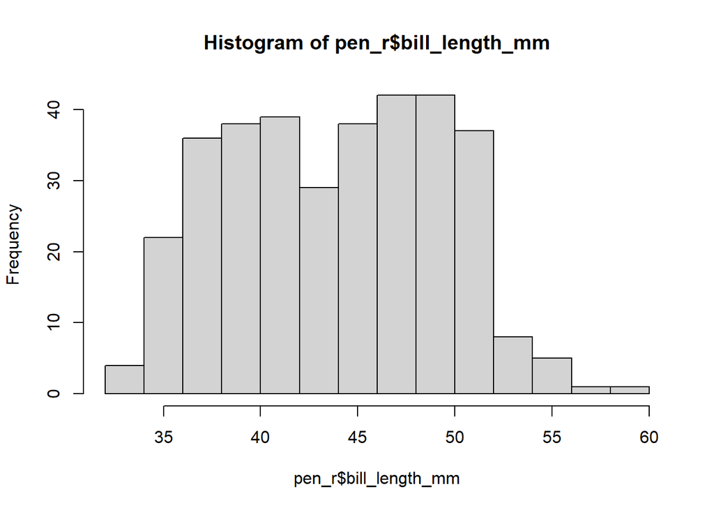

```r
hist(pen_r$bill_length_mm)
```

```r
pen_r <-
pen_r |>
  mutate(choices = case_when(bill_length_mm < 40 ~ "first",
                             bill_length_mm >= 40 & bill_length_mm < 50 ~ "second",
                             bill_length_mm >= 50 ~ "third"))

# 確認
pen_r |>
  count(choices, bill_length_mm)
```

```
## # A tibble: 165 × 3
##   choices bill_length_mm     n
##   <chr>            <dbl> <int>
## 1 first             32.1     1
## 2 first             33.1     1
## 3 first             33.5     1
## 4 first             34       1
## 5 first             34.1     1
## # … with 160 more rows
```

#### 7.7.2.2 Python

```python
## 分布確認
# import matplotlib.pyplot as plt
# pen_p[['bill_length_mm']].plt.hist()

## 条件で変数作成
import numpy as np

conditions = [
  (pen_p["bill_length_mm"].lt(40)),
  (pen_p["bill_length_mm"].ge(40) & pen_p["bill_length_mm"].lt(50)),
  (pen_p["bill_length_mm"].ge(50)),
]

choices = ["first", "second", "third"]

pen_p["blmc"] = np.select(conditions, choices)


# 確認
pen_p.value_counts(['blmc', 'bill_length_mm'])
```

```
## blmc    bill_length_mm
## second  41.1              7
##         45.2              6
## first   37.8              5
## second  46.2              5
##         45.5              5
##                          ..
##         42.3              1
##         42.1              1
##         41.8              1
##         41.7              1
## third   59.6              1
## Length: 164, dtype: int64
```

## 7.8 要約値作成

### 7.8.1 変数1つのみ

#### 7.8.1.1 R

```r
pen_r |>
  summarise(blm_mean = mean(bill_length_mm,
                            na.rm = TRUE),
            blm_sd   = sd(bill_length_mm,
                            na.rm = TRUE),
            blm_n    = sum(!is.na(bill_length_mm)))
```

```
## # A tibble: 1 × 3
##   blm_mean blm_sd blm_n
##      <dbl>  <dbl> <int>
## 1     43.9   5.46   342
```

#### 7.8.1.2 Python

- 欠損値は自動で削除して計算されている

```python
pen_p.bill_length_mm.mean()
```

```
## 43.9219298245614
```

```python
pen_p.bill_length_mm.std()
```

```
## 5.4595837139265315
```

```python
pen_p.bill_length_mm.count()
```

```
## 342
```

- [pandas.DataFrame.aggregate](https://pandas.pydata.org/docs/reference/api/pandas.DataFrame.aggregate.html#)
- 短縮して`agg`で実行できる

```python
pen_p.bill_length_mm.agg(['mean', 'std', 'count'])
```

```
## mean      43.921930
## std        5.459584
## count    342.000000
## Name: bill_length_mm, dtype: float64
```

### 7.8.2 変数複数

#### 7.8.2.1 R

```r
pen_r |>
  summarise(across(c(bill_length_mm, bill_depth_mm),
                   list(mean = ~mean(., na.rm = TRUE),
                          sd =   ~sd(., na.rm = TRUE),
                           n =  ~sum(!is.na(.)))))
```

```
## # A tibble: 1 × 6
##   bill_length_mm_mean bill_length_mm_sd bill_length_mm_n bill_depth_mm_mean
##                 <dbl>             <dbl>            <int>              <dbl>
## 1                43.9              5.46              342               17.2
## # … with 2 more variables: bill_depth_mm_sd <dbl>, bill_depth_mm_n <int>
```

```r
# 列名格納版
cols <- c("bill_length_mm", "bill_depth_mm")
pen_r |>
  summarise(across(all_of(cols),
                   list(mean = ~mean(., na.rm = TRUE),
                          sd =   ~sd(., na.rm = TRUE),
                           n =  ~sum(!is.na(.)))))
```

```
## # A tibble: 1 × 6
##   bill_length_mm_mean bill_length_mm_sd bill_length_mm_n bill_depth_mm_mean
##                 <dbl>             <dbl>            <int>              <dbl>
## 1                43.9              5.46              342               17.2
## # … with 2 more variables: bill_depth_mm_sd <dbl>, bill_depth_mm_n <int>
```

#### 7.8.2.2 Python

```python
pen_p.agg({'bill_length_mm' : ['mean', 'std', 'count'],
            'bill_depth_mm' : ['mean', 'std', 'count']})
```

```
##        bill_length_mm  bill_depth_mm
## mean        43.921930      17.151170
## std          5.459584       1.974793
## count      342.000000     342.000000
```

- 先に列選択すれば関数繰り返さなくてもよい

```python
pen_p[['bill_length_mm', 'bill_depth_mm']].agg(['mean', 'std', 'count'])

# 列名格納版
```

```
##        bill_length_mm  bill_depth_mm
## mean        43.921930      17.151170
## std          5.459584       1.974793
## count      342.000000     342.000000
```

```python
cols = ['bill_length_mm', 'bill_depth_mm']
pen_p[cols].agg(['mean', 'std', 'count'])
```

```
##        bill_length_mm  bill_depth_mm
## mean        43.921930      17.151170
## std          5.459584       1.974793
## count      342.000000     342.000000
```

### 7.8.3 グループごとに集計

#### 7.8.3.1 R

```r
pen_r |>
  group_by(species) |>
  summarise(mean_blm = mean(bill_length_mm,
                            na.rm = TRUE))
```

```
## # A tibble: 3 × 2
##   species   mean_blm
##   <fct>        <dbl>
## 1 Adelie        38.8
## 2 Chinstrap     48.8
## 3 Gentoo        47.5
```

#### 7.8.3.2 Python

```python
pen_p.groupby('species').bill_length_mm.agg('mean')
```

```
## species
## Adelie       38.791391
## Chinstrap    48.833824
## Gentoo       47.504878
## Name: bill_length_mm, dtype: float64
```

### 7.8.4 データフレーム全体

#### 7.8.4.1 R

```r
pen_r |>
  summarise(across(where(is.numeric),
    mean, na.rm = TRUE))
```

```
## # A tibble: 1 × 5
##   bill_length_mm bill_depth_mm flipper_length_mm body_mass_g  year
##            <dbl>         <dbl>             <dbl>       <dbl> <dbl>
## 1           43.9          17.2              201.       4202. 2008.
```

#### 7.8.4.2 Python

```python
pen_p.agg('mean')
```

```
## bill_length_mm         43.921930
## bill_depth_mm          17.151170
## flipper_length_mm     200.915205
## body_mass_g          4201.754386
## year                 2008.029070
## dtype: float64
##
```

### 7.8.5 度数分布

#### 7.8.5.1 R

```r
pen_r |> count(species)
```

```
## # A tibble: 3 × 2
##   species       n
##   <fct>     <int>
## 1 Adelie      152
## 2 Chinstrap    68
## 3 Gentoo      124
```

```r
pen_r |> count(sex)
```

```
## # A tibble: 3 × 2
##   sex        n
##   <fct>  <int>
## 1 female   165
## 2 male     168
## 3 <NA>      11
```

#### 7.8.5.2 Python

```python
pen_p.value_counts(['species'])
```

```
## species
## Adelie       152
## Gentoo       124
## Chinstrap     68
## dtype: int64
```

```python
pen_p.value_counts(['sex'], dropna = False)
```

```
## sex
## male      168
## female    165
## NaN        11
## dtype: int64
```

### 7.8.6 複数列の組み合わせの度数

#### 7.8.6.1 R

```r
pen_r |> count(species, sex)
```

```
## # A tibble: 8 × 3
##   species   sex        n
##   <fct>     <fct>  <int>
## 1 Adelie    female    73
## 2 Adelie    male      73
## 3 Adelie    <NA>       6
## 4 Chinstrap female    34
## 5 Chinstrap male      34
## 6 Gentoo    female    58
## 7 Gentoo    male      61
## 8 Gentoo    <NA>       5
```

#### 7.8.6.2 Python

```python
pen_p.value_counts(['species', 'sex'])
```

```
## species    sex
## Adelie     female    73
##            male      73
## Gentoo     male      61
##            female    58
## Chinstrap  female    34
##            male      34
## dtype: int64
```

### 7.8.7 クロス表

#### 7.8.7.1 R

```r
table(pen_r$species, pen_r$sex)
```

```
##
##             female male
##   Adelie        73   73
##   Chinstrap     34   34
##   Gentoo        58   61
```

#### 7.8.7.2 Python

```python
import pandas as pd
pd.crosstab(pen_p['species'], pen_p['sex'])
```

```
## sex        female  male
## species
## Adelie         73    73
## Chinstrap      34    34
## Gentoo         58    61
```

```python
pd.crosstab(pen_p.species, pen_p.sex)
```

```
## sex        female  male
## species
## Adelie         73    73
## Chinstrap      34    34
## Gentoo         58    61
```

## 7.9 動詞をつなげる

### 7.9.1 R

- `|>`でつなげる

```r
pen_r |>
  select(species, bill_length_mm) |>
  filter(species == "Gentoo")
```

```
## # A tibble: 124 × 2
##   species bill_length_mm
##   <fct>            <dbl>
## 1 Gentoo            46.1
## 2 Gentoo            50
## 3 Gentoo            48.7
## 4 Gentoo            50
## 5 Gentoo            47.6
## # … with 119 more rows
```

### 7.9.2 Python

- `.`でつなげてコード全体を`( )`で囲む

```python
(pen_p[['species', 'bill_length_mm']]
      .query('species == "Gentoo"'))
```

```
##     species  bill_length_mm
## 152  Gentoo            46.1
## 153  Gentoo            50.0
## 154  Gentoo            48.7
## 155  Gentoo            50.0
## 156  Gentoo            47.6
## ..      ...             ...
## 271  Gentoo             NaN
## 272  Gentoo            46.8
## 273  Gentoo            50.4
## 274  Gentoo            45.2
## 275  Gentoo            49.9
##
## [124 rows x 2 columns]
```

# 8 データフレームの連結や構造変換

## 8.1 データフレーム作成

### 8.1.1 R

```r
df_r_a <-
 tribble(
    ~id, ~x1, ~x2,
    1,  10,  50,
    2,  20,  60,
    3,  30,  70
  )

df_r_b <-
  tribble(
    ~id, ~x1, ~x3,
    1,  10,  80,
    2,  20,  90,
    4,  40, 100
  )

df_r_a
```

```
## # A tibble: 3 × 3
##      id    x1    x2
##   <dbl> <dbl> <dbl>
## 1     1    10    50
## 2     2    20    60
## 3     3    30    70
```

```r
df_r_b
```

```
## # A tibble: 3 × 3
##      id    x1    x3
##   <dbl> <dbl> <dbl>
## 1     1    10    80
## 2     2    20    90
## 3     4    40   100
```

### 8.1.2 Python

```python
import pandas as pd
df_py_a = pd.DataFrame([[1,10,50],
                        [2,20,60],
                        [3,30,70]],
              columns = ['id','x1','x2'])

df_py_b = pd.DataFrame([[1,10,80],
                        [2,20,90],
                        [4,40,100]],
              columns = ['id','x1','x3'])


df_py_a
```

```
##    id  x1  x2
## 0   1  10  50
## 1   2  20  60
## 2   3  30  70
```

```python
df_py_b

# または
```

```
##    id  x1   x3
## 0   1  10   80
## 1   2  20   90
## 2   4  40  100
```

```python
pd.DataFrame({'id':[1,2,3],
              'x1':[10,20,30],
              'x2':[50,60,70]})
```

```
##    id  x1  x2
## 0   1  10  50
## 1   2  20  60
## 2   3  30  70
```

## 8.2 キー変数を元に横に連結

- [dplyr::join](https://dplyr.tidyverse.org/reference/mutate-joins.html)
- [pandas.merge](https://pandas.pydata.org/docs/reference/api/pandas.merge.html#)

### 8.2.1 左に連結

#### 8.2.1.1 R

```r
df_r_a |>
  left_join(df_r_b, by = "id")
```

```
## # A tibble: 3 × 5
##      id  x1.x    x2  x1.y    x3
##   <dbl> <dbl> <dbl> <dbl> <dbl>
## 1     1    10    50    10    80
## 2     2    20    60    20    90
## 3     3    30    70    NA    NA
```

#### 8.2.1.2 Python

```python
pd.merge(df_py_a, df_py_b, on = 'id', how = 'left')
```

```
##    id  x1_x  x2  x1_y    x3
## 0   1    10  50  10.0  80.0
## 1   2    20  60  20.0  90.0
## 2   3    30  70   NaN   NaN
```

### 8.2.2 すべて連結

#### 8.2.2.1 R

```r
df_r_a |>
  full_join(df_r_b)
```

```
## # A tibble: 4 × 4
##      id    x1    x2    x3
##   <dbl> <dbl> <dbl> <dbl>
## 1     1    10    50    80
## 2     2    20    60    90
## 3     3    30    70    NA
## 4     4    40    NA   100
```

#### 8.2.2.2 Python

```python
pd.merge(df_py_a, df_py_b, how = 'outer')
```

```
##    id  x1    x2     x3
## 0   1  10  50.0   80.0
## 1   2  20  60.0   90.0
## 2   3  30  70.0    NaN
## 3   4  40   NaN  100.0
```

### 8.2.3 共通するデータの連結

#### 8.2.3.1 R

```r
df_r_a |>
  inner_join(df_r_b)
```

```
## # A tibble: 2 × 4
##      id    x1    x2    x3
##   <dbl> <dbl> <dbl> <dbl>
## 1     1    10    50    80
## 2     2    20    60    90
```

#### 8.2.3.2 Python

```python
pd.merge(df_py_a, df_py_b, how = 'inner')
```

```
##    id  x1  x2  x3
## 0   1  10  50  80
## 1   2  20  60  90
```

## 8.3 縦に連結

### 8.3.1 R

```r
# 連結用データ作成
df_r_b2 <-
  tribble(
    ~id, ~x1, ~x2, ~x3,
    4,  40, 80,  110,
    5,  50, 90,  120,
    6,  60, 100, 130
  )

df_r_b2
```

```
## # A tibble: 3 × 4
##      id    x1    x2    x3
##   <dbl> <dbl> <dbl> <dbl>
## 1     4    40    80   110
## 2     5    50    90   120
## 3     6    60   100   130
```

```r
# 縦に連結
df_r_a |>
  bind_rows(df_r_b2)
```

```
## # A tibble: 6 × 4
##      id    x1    x2    x3
##   <dbl> <dbl> <dbl> <dbl>
## 1     1    10    50    NA
## 2     2    20    60    NA
## 3     3    30    70    NA
## 4     4    40    80   110
## 5     5    50    90   120
## 6     6    60   100   130
```

#### 8.3.1.1 連結元データを示すidを付与

```r
df_r_a |>
  bind_rows(df_r_b2, .id = "df_id")
```

```
## # A tibble: 6 × 5
##   df_id    id    x1    x2    x3
##   <chr> <dbl> <dbl> <dbl> <dbl>
## 1 1         1    10    50    NA
## 2 1         2    20    60    NA
## 3 1         3    30    70    NA
## 4 2         4    40    80   110
## 5 2         5    50    90   120
## 6 2         6    60   100   130
```

- データフレーム名を付けたければ，一旦データフレームをリストに

```r
df_r_l <- list(df_r_a, df_r_b2) |>
  set_names("df_r_a", "df_r_b2")

bind_rows(df_r_l, .id = "df_id")
```

```
## # A tibble: 6 × 5
##   df_id      id    x1    x2    x3
##   <chr>   <dbl> <dbl> <dbl> <dbl>
## 1 df_r_a      1    10    50    NA
## 2 df_r_a      2    20    60    NA
## 3 df_r_a      3    30    70    NA
## 4 df_r_b2     4    40    80   110
## 5 df_r_b2     5    50    90   120
## 6 df_r_b2     6    60   100   130
```

### 8.3.2 Python

```python
# 連結用データ作成
df_py_b2 = pd.DataFrame([[4,40,80,110],
                         [5,50,90,120],
                         [6,60,100,130]],
              columns = ['id','x1','x2','x3'])

df_py_b2

# 縦に連結
```

```
##    id  x1   x2   x3
## 0   4  40   80  110
## 1   5  50   90  120
## 2   6  60  100  130
```

```python
pd.concat([df_py_a, df_py_b2])
```

```
##    id  x1   x2     x3
## 0   1  10   50    NaN
## 1   2  20   60    NaN
## 2   3  30   70    NaN
## 0   4  40   80  110.0
## 1   5  50   90  120.0
## 2   6  60  100  130.0
```

#### 8.3.2.1 連結元データを示すidを付与

```python
pd.concat([df_py_a, df_py_b2],
          keys = ['df_py_a', 'df_py_b2'])
```

```
##             id  x1   x2     x3
## df_py_a  0   1  10   50    NaN
##          1   2  20   60    NaN
##          2   3  30   70    NaN
## df_py_b2 0   4  40   80  110.0
##          1   5  50   90  120.0
##          2   6  60  100  130.0
```

## 8.4 縦横構造の変換

### 8.4.1 long形式に

#### 8.4.1.1 R

```r
df_r_a_long <-
df_r_a |>
pivot_longer(!id,
             names_to = "変数",
             values_to = "得点")

df_r_a_long
```

```
## # A tibble: 6 × 3
##      id 変数   得点
##   <dbl> <chr> <dbl>
## 1     1 x1       10
## 2     1 x2       50
## 3     2 x1       20
## 4     2 x2       60
## 5     3 x1       30
## 6     3 x2       70
```

#### 8.4.1.2 Python

```python
df_py_a_long = pd.melt(df_py_a,
                           id_vars = ['id'],
                           var_name = '変数',
                           value_name = '得点')

df_py_a_long
```

```
##    id  変数  得点
## 0   1  x1  10
## 1   2  x1  20
## 2   3  x1  30
## 3   1  x2  50
## 4   2  x2  60
## 5   3  x2  70
```

### 8.4.2 wide形式に

#### 8.4.2.1 R

```r
df_r_a_long |>
  pivot_wider(names_from = 変数,
              values_from = 得点)
```

```
## # A tibble: 3 × 3
##      id    x1    x2
##   <dbl> <dbl> <dbl>
## 1     1    10    50
## 2     2    20    60
## 3     3    30    70
```

#### 8.4.2.2 Python

```python
df_py_a_long.pivot(index = ['id'],
                   columns = ['変数'],
                   values  = ['得点'])
```

```
##     得点
## 変数  x1  x2
## id
## 1   10  50
## 2   20  60
## 3   30  70
```

# 9 ファイルの読み込み

## 9.1 Excelファイル

### 9.1.1 R

```r
readxl::read_xlsx("data/ペンギン.xlsx")
```

```
## # A tibble: 344 × 9
##   species 種類  island bill_length_mm bill_depth_mm flipper_length_… body_mass_g
##   <chr>   <chr> <chr>           <dbl>         <dbl>            <dbl>       <dbl>
## 1 Adelie  アデ… Torge…           39.1          18.7              181        3750
## 2 Adelie  アデ… Torge…           39.5          17.4              186        3800
## 3 Adelie  アデ… Torge…           40.3          18                195        3250
## 4 Adelie  アデ… Torge…           NA            NA                 NA          NA
## 5 Adelie  アデ… Torge…           36.7          19.3              193        3450
## # … with 339 more rows, and 2 more variables: sex <chr>, year <dbl>
```

### 9.1.2 Python

```python
pd.read_excel('data/ペンギン.xlsx')
```

```
##        species    種類     island  ...  body_mass_g     sex  year
## 0       Adelie  アデリー  Torgersen  ...       3750.0    male  2007
## 1       Adelie  アデリー  Torgersen  ...       3800.0  female  2007
## 2       Adelie  アデリー  Torgersen  ...       3250.0  female  2007
## 3       Adelie  アデリー  Torgersen  ...          NaN     NaN  2007
## 4       Adelie  アデリー  Torgersen  ...       3450.0  female  2007
## ..         ...   ...        ...  ...          ...     ...   ...
## 339  Chinstrap    ヒゲ      Dream  ...       4000.0    male  2009
## 340  Chinstrap    ヒゲ      Dream  ...       3400.0  female  2009
## 341  Chinstrap    ヒゲ      Dream  ...       3775.0    male  2009
## 342  Chinstrap    ヒゲ      Dream  ...       4100.0    male  2009
## 343  Chinstrap    ヒゲ      Dream  ...       3775.0  female  2009
##
## [344 rows x 9 columns]
```

## 9.2 csvファイル

### 9.2.1 utf-8

#### 9.2.1.1 R

```r
penr_csv <-
read_csv("data/ペンギン（ひどい列名）ver_utf8.csv")

penr_csv
```

```
## # A tibble: 344 × 9
##   Sｐｅｃｉｅｓ `種　類` `※島の名前` `①クチバシ　長さ（ｍｍ）` `②ｸﾁﾊﾞｼ＿大きさ…`
##   <chr>         <chr>    <chr>                           <dbl>             <dbl>
## 1 Adelie        アデリー Torgersen                        39.1              18.7
## 2 Adelie        アデリー Torgersen                        39.5              17.4
## 3 Adelie        アデリー Torgersen                        40.3              18
## 4 Adelie        アデリー Torgersen                        NA                NA
## 5 Adelie        アデリー Torgersen                        36.7              19.3
## # … with 339 more rows, and 4 more variables: `翼：長さ(mm)` <dbl>,
## #   `■体重　単位はｇ` <dbl>, `㊛㊚` <chr>, `２００７～２００９` <dbl>
```

#### 9.2.1.2 Python

```python
penp_csv = pd.read_csv('data/ペンギン（ひどい列名）ver_utf8.csv')

penp_csv
```

```
##        Sｐｅｃｉｅｓ   種　類      ※島の名前  ...  ■体重　単位はｇ      ㊛㊚  ２００７～２００９
## 0       Adelie  アデリー  Torgersen  ...    3750.0    male       2007
## 1       Adelie  アデリー  Torgersen  ...    3800.0  female       2007
## 2       Adelie  アデリー  Torgersen  ...    3250.0  female       2007
## 3       Adelie  アデリー  Torgersen  ...       NaN     NaN       2007
## 4       Adelie  アデリー  Torgersen  ...    3450.0  female       2007
## ..         ...   ...        ...  ...       ...     ...        ...
## 339  Chinstrap    ヒゲ      Dream  ...    4000.0    male       2009
## 340  Chinstrap    ヒゲ      Dream  ...    3400.0  female       2009
## 341  Chinstrap    ヒゲ      Dream  ...    3775.0    male       2009
## 342  Chinstrap    ヒゲ      Dream  ...    4100.0    male       2009
## 343  Chinstrap    ヒゲ      Dream  ...    3775.0  female       2009
##
## [344 rows x 9 columns]
```

### 9.2.2 shift-jis(cp932)

#### 9.2.2.1 R

```r
read_csv("data/ペンギン（ひどい列名）ver_cp932.csv",
         locale = locale(encoding = "cp932"))
```

```
## # A tibble: 344 × 9
##   Sｐｅｃｉｅｓ `種　類` `※島の名前` `①クチバシ　長さ（ｍｍ）` `②ｸﾁﾊﾞｼ＿大きさ…`
##   <chr>         <chr>    <chr>                           <dbl>             <dbl>
## 1 Adelie        アデリー Torgersen                        39.1              18.7
## 2 Adelie        アデリー Torgersen                        39.5              17.4
## 3 Adelie        アデリー Torgersen                        40.3              18
## 4 Adelie        アデリー Torgersen                        NA                NA
## 5 Adelie        アデリー Torgersen                        36.7              19.3
## # … with 339 more rows, and 4 more variables: `翼：長さ(mm)` <dbl>,
## #   `■体重　単位はｇ` <dbl>, `??` <chr>, `２００７～２００９` <dbl>
```

#### 9.2.2.2 Python

```python
pd.read_csv('data/ペンギン（ひどい列名）ver_cp932.csv',
             encoding = 'cp932')
```

```
##        Sｐｅｃｉｅｓ   種　類      ※島の名前  ...  ■体重　単位はｇ      ??  ２００７～２００９
## 0       Adelie  アデリー  Torgersen  ...    3750.0    male       2007
## 1       Adelie  アデリー  Torgersen  ...    3800.0  female       2007
## 2       Adelie  アデリー  Torgersen  ...    3250.0  female       2007
## 3       Adelie  アデリー  Torgersen  ...       NaN     NaN       2007
## 4       Adelie  アデリー  Torgersen  ...    3450.0  female       2007
## ..         ...   ...        ...  ...       ...     ...        ...
## 339  Chinstrap    ヒゲ      Dream  ...    4000.0    male       2009
## 340  Chinstrap    ヒゲ      Dream  ...    3400.0  female       2009
## 341  Chinstrap    ヒゲ      Dream  ...    3775.0    male       2009
## 342  Chinstrap    ヒゲ      Dream  ...    4100.0    male       2009
## 343  Chinstrap    ヒゲ      Dream  ...    3775.0  female       2009
##
## [344 rows x 9 columns]
```